# Oravecz & Muth (2017). Fitting growth curve models in the Bayesian framework. Psychonomic Bulletin and Review

ExpORL Journal Club

Tobias Busch

July 19 2017

## Introduction

This is a Bayesian Growth Curve analysis, following the tutorial by [Oravecz & Muth (2017)](https://doi.org/10.3758/s13423-017-1281-0). The paper’s accompanying git repository can be found [here](https://git.psu.edu/zzo1/FittingGCMBayesian). In some places the code has been adapted to be more concise.

**Note:** This analysis requires a working installation of the Bayesian sampling engine [JAGS](http://mcmc-jags.sourceforge.net/).

```r
library(tidyverse)
library(stringr)
library(rjags)
knitr::opts_chunk$set(results = "hold", strip.white = F)
# Set ggplot theme for the this notebook
theme_set(theme_grey() +
          theme(panel.grid.major.y = element_blank(),
                panel.grid.minor.y = element_blank(),
                panel.grid.minor.x = element_blank()
                )
          )
```

## load and clean marital love data set

We load the data and change it into long format (more convenient), add subject id, and use less cryptic column and factor level names.

```r
loveData <- read.csv("lovedata.csv")
loveData <- loveData %>%
  rename(posFactor = PosFactor,     # father's positivity group
         lowPos = X1,               # the 2 dummy coding variables for 3-level positivity factor
         highPos = X2) %>%
  mutate(subject = as.factor(row_number()),
         posFactor = recode_factor(posFactor, "1"="Low", "2"="Medium", "3"="High") %>%
           C(base=2)) %>%
  select(subject, everything())     # reorder columns
# make long format
loveData <- loveData %>%
  gather(key = month, value = score, M1:M4) %>%
  mutate(month = recode(month, "M1"=-3, "M2"=3, "M3"=9, "M4"=36)) # measurement moment (mo. after birth)
contrasts(loveData$posFactor)   # Check: is 'Medium' reference level?
```

```
       1 3
Low    1 0
Medium 0 0
High   0 1
```

```r
loveData
```

| subject | posFactor | lowPos | highPos | month | score |
| --- | --- | --- | --- | --- | --- |
| 1 | High | 0 | 1 | -3 | 79 |
| 2 | High | 0 | 1 | -3 | 80 |
| 3 | High | 0 | 1 | -3 | 81 |
| 4 | Low | 1 | 0 | -3 | 78 |
| 5 | Low | 1 | 0 | -3 | 78 |
| 6 | Medium | 0 | 0 | -3 | 79 |
| 7 | Low | 1 | 0 | -3 | 65 |
| 8 | High | 0 | 1 | -3 | 77 |
| 9 | Medium | 0 | 0 | -3 | 69 |
| 10 | Medium | 0 | 0 | -3 | 74 |

[output cut: 422 more lines]

## Plot observed data

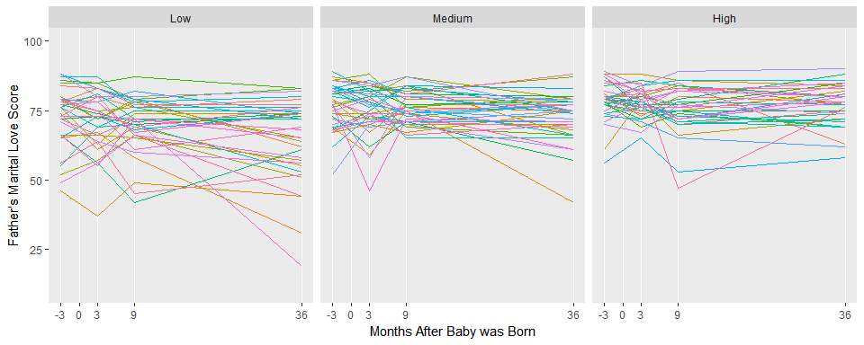

```r
loveData %>%
  ggplot(aes(month, score, group = subject)) +
    geom_line(aes(col = subject), show.legend = F, lty="solid") +
    facet_grid(~posFactor) +
    scale_x_continuous(name = "Months After Baby was Born", breaks = c(-3, 0, 3, 9, 36)) +
    scale_y_continuous(name = "Father's Marital Love Score", limits = c(10,100))
```

```r
ggsave("out/observed.png", width = 10, height = 4)
```

## Prepare data for JAGS

For JAGS all data that the model should use needs to be in the form of a named list.

```r
jagsData <- list(
  "nObservations" = nrow(loveData),               # number of observations
  "nSubjects" = length(unique(loveData$subject)), # number of subjects (fathers)
  "subject" = loveData$subject,                   # subject id of observation
  "time" = loveData$month,                        # month of observation
  "lowPos" = loveData$lowPos,                     # dummy var.s for positivity factor
  "highPos" = loveData$highPos,
  "score" = loveData$score                        # dv: father's marital love score
)
glimpse(jagsData)
```

```
List of 7
 $ nObservations: int 432
 $ nSubjects    : int 108
 $ subject      : Factor w/ 108 levels "1","2","3","4",..: 1 2 3 4 5 6 7 8 9 10 ...
 $ time         : num [1:432] -3 -3 -3 -3 -3 -3 -3 -3 -3 -3 ...
 $ lowPos       : int [1:432] 0 0 0 1 1 0 1 0 0 0 ...
 $ highPos      : int [1:432] 1 1 1 0 0 0 0 1 0 0 ...
 $ score        : int [1:432] 79 80 81 78 78 79 65 77 69 74 ...
```

## Specify model in BUGS modeling language

JAGS uses the BUGS modeling language to specify models. (Win)BUGS is a software similar to JAGS. Martyn Plummer, the author of JAGS used to work on BUGS before. Note that for JAGS uses precision instead of variance to parameterize distributions. Precision is simply the inverse of the variance (1/s^2).

```r
GCM <- "
model {
# Loop over observations
for (i in 1:nObservations) {
  # Likelihood Function (assumed data generating distribution), Eq. 1
  score[i] ~ dnorm(betas[subject[i],1] + betas[subject[i],2]*time[i], 1/pow(sdLevel1Error,2))
}
# Loop over subjects
for (j in 1:nSubjects) {
  level2MeanVector[j,1] <- medPInt + betaLowPInt*lowPos[j] + betaHighPInt*highPos[j]
  level2MeanVector[j,2] <- medPSlope + betaLowPSlope*lowPos[j] + betaHighPSlope*highPos[j]
  # Level 2 bivariate distribution of intercepts and slopes, Eq. 6
  betas[j,1:2] ~ dmnorm(level2MeanVector[j,1:2], interpersonPrecisionMatrix[1:2,1:2])
}
# Prior distributions
medPInt ~ dnorm(0,0.01)
medPSlope ~ dnorm(0,0.01)
betaLowPInt ~ dnorm(0,0.01)
betaLowPSlope ~ dnorm(0,0.01)
betaHighPInt ~ dnorm(0,0.01)
betaHighPSlope ~ dnorm(0,0.01)
sdLevel1Error ~ dunif(0,100)
sdIntercept ~ dunif(0,100)
sdSlope ~ dunif(0,100)
corrIntSlope ~ dunif(-1,1)
# Transforming model parameters
interpersonCovMatrix[1,1] = pow(sdIntercept,2)
interpersonCovMatrix[2,2] = pow(sdSlope,2)
interpersonCovMatrix[1,2] = corrIntSlope * sdIntercept * sdSlope
interpersonCovMatrix[2,1] = interpersonCovMatrix[1,2]
interpersonPrecisionMatrix <- inverse(interpersonCovMatrix)
# We also keep track of other parameters of interest
# (not obligatory for the model to run, but useful for us)
# High and low positivity slopes and intercepts
lowPInt <- medPInt + betaLowPInt
highPInt <- medPInt + betaHighPInt
lowPSlope <- medPSlope + betaLowPSlope
highPSlope <- medPSlope + betaHighPSlope
# planned comparisons - contrasts between low, mid, and high intercepts and slopes
c_highLowPInt <- betaHighPInt - betaLowPInt
c_medLowPInt <- - betaLowPInt
c_highMedPInt <- betaHighPInt
c_highLowPSlope <- betaHighPSlope - betaLowPSlope
c_medLowPSlope <- - betaLowPSlope
c_highMedPSlope <- betaHighPSlope
}
"
# the model code needs to be saved in a file that is then read by the jags function
cat(GCM, file = "loveModel.bugs")
```

## Specify the modeling and sampling parameters

```r
# the parameters we want to monitor
parameters <- c("lowPInt", "medPInt", "highPInt",
                "lowPSlope", "medPSlope", "highPSlope",
                "betaLowPInt", "betaHighPInt", "betaLowPSlope", "betaHighPSlope",
                "sdIntercept", "sdSlope", "corrIntSlope", "sdLevel1Error",
                "c_highLowPInt", "c_highMedPInt", "c_medLowPInt",
                "c_highLowPSlope", "c_highMedPSlope", "c_medLowPSlope",
                "betas")
# set random number generators and seeds (optional, for reproducibility)
inits <- list(
  list(.RNG.seed=5,.RNG.name="base::Mersenne-Twister"),
  list(.RNG.seed=6,.RNG.name="base::Mersenne-Twister"),
  list(.RNG.seed=7,.RNG.name="base::Mersenne-Twister"),
  list(.RNG.seed=8,.RNG.name="base::Mersenne-Twister"),
  list(.RNG.seed=9,.RNG.name="base::Mersenne-Twister"),
  list(.RNG.seed=10,.RNG.name="base::Mersenne-Twister"))
# other parameters for the model / sampling
nAdapt <- 2000              # n iterations for algorithm to adapt to data/model
nBurnIn <- 1000             # n burn-in iterations
postSamples <- 30000        # how many samples we want in total
thinning <- 5               # thinning interval
nChains <- 6                # how many sampling chains
nIter <- ceiling((postSamples * thinning)/nChains)
# initialize the model
mdl <- jags.model("loveModel.bugs", jagsData, n.chains = nChains, n.adapt = nAdapt, inits = inits, quiet = T)
```

## Get the samples

We sample from our parameters posterior distribution via the MCMC algorithm implemented in JAGS.

```r
t <- Sys.time()
# run run burn-in iterations
update(mdl, n.iter = nBurnIn, progress.bar = "gui")
# sample from the posterior distribution
codaSamples <- coda.samples(mdl,
                            variable.names = parameters,
                            n.iter = nIter,
                            thin = thinning,
                            seed = 5,
                            progress.bar = "gui")
Sys.time() - t # How long did it take to get the samples?
```

```
Time difference of 7.677417 mins
```

## Save samples for later use

If needed, save and load samples from previous run of the model to save time.

```r
save(codaSamples, file = "out/loveModelSamples.save", compress = T)
load("loveModelSamples.save")
```